# Cumulative looking plots

Rick Gilmore

2020-09-25 08:29:53

# Purpose

# Setup

## Finding data

The relevant data are in Box.

The parent project folder is `~/Box/R01 Project 2 Data for Yiming&Rick/R01A-C files for transitional probabilities/`, and the files are in `.xlsx` format.

## Relevant packages

We’ll use the `readxl` package from the `tidyverse` group of packages.

```r
if (!require(readxl)){
  install.packages(readxl)
}
```

# Import data

```r
fix_files <- list.files('~/Box/R01 Project 2 Data for Yiming&Rick/R01A-C files for transitional probabilities', pattern = '\\.xlsx$', full.names = TRUE)

fix_files
```

```
## [1] "/Users/rog1/Box/R01 Project 2 Data for Yiming&Rick/R01A-C files for transitional probabilities/R01_A_Data_Export_DS_newAOInames.xlsx"
## [2] "/Users/rog1/Box/R01 Project 2 Data for Yiming&Rick/R01A-C files for transitional probabilities/R01_A_Data_Export_TD_newAOInames.xlsx"
## [3] "/Users/rog1/Box/R01 Project 2 Data for Yiming&Rick/R01A-C files for transitional probabilities/R01_B_Data_Export_DS_NewAOInames.xlsx"
## [4] "/Users/rog1/Box/R01 Project 2 Data for Yiming&Rick/R01A-C files for transitional probabilities/R01_B_Data_Export_TD_newAOInames.xlsx"
## [5] "/Users/rog1/Box/R01 Project 2 Data for Yiming&Rick/R01A-C files for transitional probabilities/R01_C_Data_Export_DS_newAOInames.xlsx"
```

Let’s import the first file and explore its contents.

**Set this chunk to `eval=FALSE` since we know import does not work**

```r
f_basename <- basename(fix_files[1])
f_trimname <- stringr::str_remove(f_basename[1], pattern = '\\.xlsx')
f_trimname

a_ds_df <- read_xls(fix_files[1])
```

Ok, that did not work. Let’s open in Excel and see what’s going on. The file is large (10.4 MB). That could be a problem.

I manually exported it as a CSV.

```r
csv_files <- list.files('~/Box/R01 Project 2 Data for Yiming&Rick/R01A-C files for transitional probabilities', pattern = '\\.csv$', full.names = TRUE)
csv_files
```

```
## [1] "/Users/rog1/Box/R01 Project 2 Data for Yiming&Rick/R01A-C files for transitional probabilities/freq_start.csv"
## [2] "/Users/rog1/Box/R01 Project 2 Data for Yiming&Rick/R01A-C files for transitional probabilities/R01_A_Data_Export_DS_newAOInames.csv"
```

Let’s see if we can import the CSV.

```r
a_ds_df <- readr::read_csv(csv_files[2])
```

[output not shown]

Yes, that seems to have worked.

We now list the column names to determine what to keep and what to drop.

```r
names(a_ds_df)
```

```
##    [1] "StudioProjectName"              "StudioTestName"
##    [3] "ParticipantName"                "[Participant Type]Value"
##    [5] "MediaName"                      "RecordingTimestamp"
##    [7] "MouseEventIndex"                "MouseEvent"
##    [9] "MouseEventX (ADCSpx)"           "MouseEventY (ADCSpx)"
##   [11] "MouseEventX (MCSpx)"            "MouseEventY (MCSpx)"
##   [13] "FixationIndex"                  "GazeEventType"
##   [15] "GazeEventDuration"              "FixationPointX (MCSpx)"
##   [17] "FixationPointY (MCSpx)"         "AOI[1C-WIDE-SWING]Hit"
##   [19] "AOI[1B-WIDE-HAPPY-2]Hit"        "AOI[1A-WIDE-HOT]Hit"
##   [21] "AOI[1B-WIDE-SAD-1]Hit"          "AOI[1B-WIDE-COLD-1]Hit"
##   [23] "AOI[1C-WIDE-GIRL]Hit"           "AOI[1C-WIDE-BABY]Hit"
##   [25] "AOI[1C-WIDE-BOY]Hit"            "AOI[1C-WIDE-ME]Hit"
##   [27] "AOI[1C-WIDE-CLIMBING]Hit"       "AOI[1C-WIDE-THROWING]Hit"
##   [29] "AOI[1C-WIDE-SWINGING]Hit"       "AOI[1C-WIDE-LADDER]Hit"
```

[output cut: 538 more lines]

For a first pass, let’s keep columns 3-17:

[3] “ParticipantName”  
[4] “[Participant Type]Value”  
[5] “MediaName”  
[6] “RecordingTimestamp”  
[7] “MouseEventIndex”  
[8] “MouseEvent”  
[9] “MouseEventX (ADCSpx)”  
[10] “MouseEventY (ADCSpx)”  
[11] “MouseEventX (MCSpx)”  
[12] “MouseEventY (MCSpx)”  
[13] “FixationIndex”  
[14] “GazeEventType”  
[15] “GazeEventDuration”  
[16] “FixationPointX (MCSpx)”  
[17] “FixationPointY (MCSpx)”

```r
a_ds_trim <- a_ds_df[,3:17]
```

How many participants?

```r
unique(a_ds_trim$ParticipantName)
```

```
## [1] "TR"      "BF"      "CB_SV"   "HGR_UP2" "AHV_UP"
```

Ok, let’s see the structure of these data.

```r
str(a_ds_trim)
```

```
## tibble [180,343 × 15] (S3: tbl_df/tbl/data.frame)
##  $ ParticipantName        : chr [1:180343] "TR" "TR" "TR" "TR" ...
##  $ [Participant Type]Value: num [1:180343] 2 2 2 2 2 2 2 2 2 2 ...
##  $ MediaName              : chr [1:180343] NA NA NA NA ...
##  $ RecordingTimestamp     : num [1:180343] 9 25 42 59 75 92 109 125 142 158 ...
##  $ MouseEventIndex        : num [1:180343] NA NA NA NA NA NA NA NA NA NA ...
##  $ MouseEvent             : chr [1:180343] NA NA NA NA ...
##  $ MouseEventX (ADCSpx)   : num [1:180343] NA NA NA NA NA NA NA NA NA NA ...
##  $ MouseEventY (ADCSpx)   : num [1:180343] NA NA NA NA NA NA NA NA NA NA ...
##  $ MouseEventX (MCSpx)    : num [1:180343] NA NA NA NA NA NA NA NA NA NA ...
##  $ MouseEventY (MCSpx)    : num [1:180343] NA NA NA NA NA NA NA NA NA NA ...
##  $ FixationIndex          : num [1:180343] NA 1 1 1 1 1 1 1 1 1 ...
##  $ GazeEventType          : chr [1:180343] NA "Fixation" "Fixation" "Fixation" ...
##  $ GazeEventDuration      : num [1:180343] NA 233 233 233 233 233 233 233 233 233 ...
##  $ FixationPointX (MCSpx) : num [1:180343] NA NA NA NA NA NA NA NA NA NA ...
##  $ FixationPointY (MCSpx) : num [1:180343] NA NA NA NA NA NA NA NA NA NA ...
```

I’m going to guess that `RecordingTimestamp` is time in ms from the start of the study.

Let’s look at `MediaName`.

```r
unique(a_ds_trim$MediaName)
```

```
##   [1] NA                    "Slide03.jpg"         "Mary_hot.wmv"
##   [4] "White_wide.png"      "Paul_theswing.wmv"   "White_SOC.png"
##   [7] "Ellie_sad.wmv"       "White_clock.png"     "Matt_theladder.wmv"
##  [10] "White_wide_2.png"    "Pete_baby.wmv"       "White_clock_2.png"
##  [13] "greatjob_stars.jpg"  "Pete_cold.wmv"       "White_corners.png"
##  [16] "Mary_theball.wmv"    "White_clock_3.png"   "Joe_boy.wmv"
##  [19] "White_wide_3.png"    "Paul_cold.wmv"       "White_clock_4.png"
##  [22] "Joe_theswing.wmv"    "White_corners_2.png" "greatjob_star2.jpg"
##  [25] "Matt_boy.wmv"        "White_clock_5.png"   "Anna_theslide.wmv"
##  [28] "White_clock_6.png"   "Henry_baby.wmv"      "White_SOC_2.png"
##  [31] "Anna_hot.wmv"        "White_SOC_3.png"     "Paul_swinging.wmv"
##  [34] "White_corners_3.png" "good-job.png"        "Mary_girl.wmv"
##  [37] "White_SOC_4.png"     "Matt_happy.wmv"      "White_corners_4.png"
##  [40] "Joe_swinging.wmv"    "White_clock_7.png"   "Matt_climbing.wmv"
##  [43] "White_SOC_5.png"     "Henry_throwing.wmv"  "White_clock_8.png"
```

[output cut: 19 more lines]

I think that the `*.wmv` values are the movies that gave the auditory cue for the subsequent search. The subsequent searches were then on `{White,Color}_{wide,SOC,corners,Clock}_[2-8].png` If this is correct, we can eliminate rows that do not have `.png` in the `MediaName`.

```r
a_ds <- a_ds_trim %>%
  dplyr::filter(., stringr::str_detect(MediaName, pattern = '\\.png'))
```

Now, let’s generate new variables for the background condition {White,Color} and the layout {wide,SOC,corners,Clock}.

```r
a_ds <- a_ds %>%
  dplyr::mutate(., bgnd = stringr::str_extract(MediaName, pattern='Color|White')) %>%
  dplyr::mutate(., layout = stringr::str_extract(MediaName, pattern='wide|SOC|corners|Clock')) %>%
  dplyr::mutate(cond_index = stringr::str_extract(MediaName, pattern='[0-9]'))

# Convert NA to "1"
a_ds <- a_ds %>%
  dplyr::mutate(., cond_index = if_else(is.na(cond_index), "1", cond_index))

unique(a_ds$cond_index)
```

```
## [1] "1" "2" "3" "4" "5" "6" "7" "8"
```

# Plot one participant and one condition

List unique participants again.

```r
unique(a_ds$ParticipantName)
```

```
## [1] "TR"      "BF"      "CB_SV"   "HGR_UP2" "AHV_UP"
```

```r
this_participant <- unique(a_ds$ParticipantName)[1]
```

Let’s also pick the display condition factors, `bgnd` and `layout`.

```r
(this_bgnd <- unique(a_ds$bgnd)[1])
```

```
## [1] "White"
```

```r
(this_layout <- unique(a_ds$layout)[1])
```

```
## [1] "wide"
```

Select fixations for this trial.

```r
this_trial <- a_ds %>%
  filter(., ParticipantName == this_participant,
         bgnd == this_bgnd,
         layout == this_layout)

str(this_trial)
```

```
## tibble [1,052 × 18] (S3: tbl_df/tbl/data.frame)
##  $ ParticipantName        : chr [1:1052] "TR" "TR" "TR" "TR" ...
##  $ [Participant Type]Value: num [1:1052] 2 2 2 2 2 2 2 2 2 2 ...
##  $ MediaName              : chr [1:1052] "White_wide.png" "White_wide.png" "White_wide.png" "White_wide.png" ...
##  $ RecordingTimestamp     : num [1:1052] 9951 9968 9984 10001 10018 ...
##  $ MouseEventIndex        : num [1:1052] NA NA NA NA NA NA NA NA NA NA ...
##  $ MouseEvent             : chr [1:1052] NA NA NA NA ...
##  $ MouseEventX (ADCSpx)   : num [1:1052] NA NA NA NA NA NA NA NA NA NA ...
##  $ MouseEventY (ADCSpx)   : num [1:1052] NA NA NA NA NA NA NA NA NA NA ...
##  $ MouseEventX (MCSpx)    : num [1:1052] NA NA NA NA NA NA NA NA NA NA ...
##  $ MouseEventY (MCSpx)    : num [1:1052] NA NA NA NA NA NA NA NA NA NA ...
##  $ FixationIndex          : num [1:1052] 26 26 27 27 27 27 27 27 27 27 ...
##  $ GazeEventType          : chr [1:1052] "Fixation" "Fixation" "Fixation" "Fixation" ...
##  $ GazeEventDuration      : num [1:1052] 117 117 216 216 216 216 216 216 216 216 ...
##  $ FixationPointX (MCSpx) : num [1:1052] NA NA NA NA NA NA NA NA NA NA ...
##  $ FixationPointY (MCSpx) : num [1:1052] NA NA NA NA NA NA NA NA NA NA ...
##  $ bgnd                   : chr [1:1052] "White" "White" "White" "White" ...
##  $ layout                 : chr [1:1052] "wide" "wide" "wide" "wide" ...
##  $ cond_index             : chr [1:1052] "1" "1" "1" "1" ...
```

It looks like the `FixationIndex` changes more slowly than the `RecordingTimestamp` variable.

Let’s plot `GazeEventDuration` by `FixationIndex`.

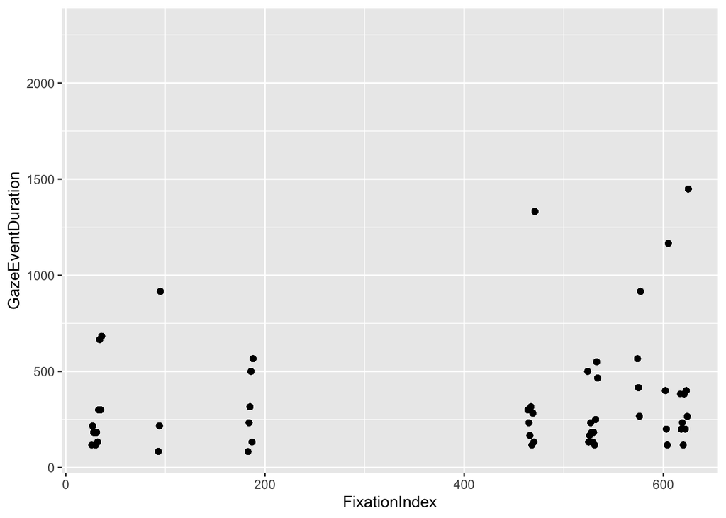

```r
this_trial %>%
  ggplot(.) +
  aes(x=FixationIndex, y=GazeEventDuration) +
  geom_point()
```

There’s a big gap in `FixationIndex`. Let’s look at this variable more closely.

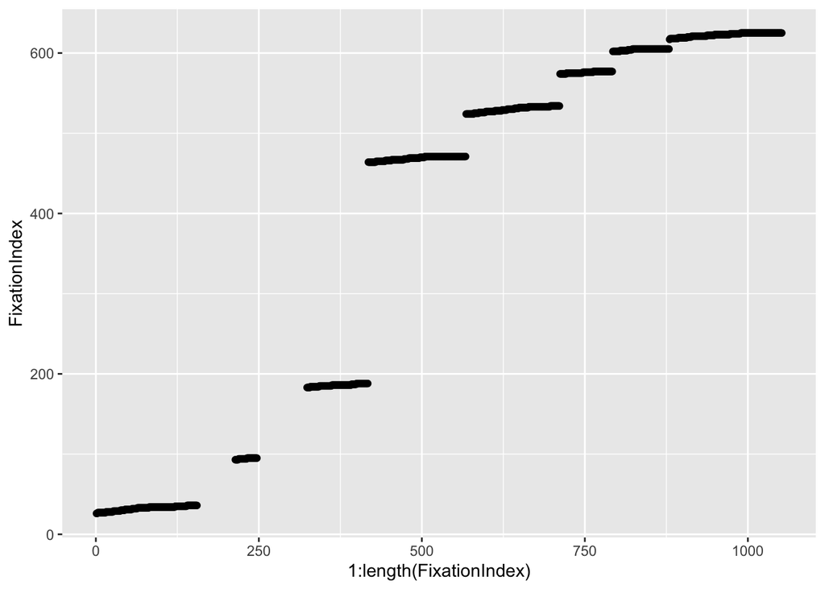

```r
this_trial %>%
  ggplot(.) +
  aes(x = 1:length(FixationIndex), y = FixationIndex) +
  geom_point()
```

Let’s look at the `RecordingTimestamp` and `FixationIndex`.

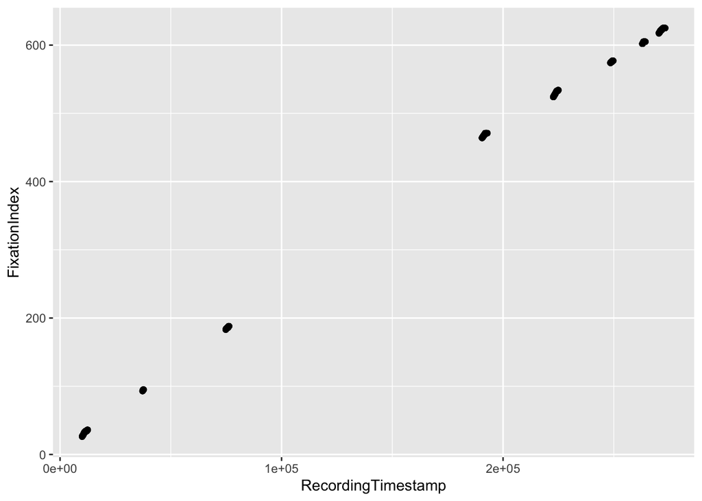

```r
this_trial %>%
  ggplot(.) +
  aes(x = RecordingTimestamp, y = FixationIndex) +
  geom_point()
```

Ok. There’s definitely a considerable gap. I wonder whether I’ve combined two trials somehow.

It should still be possible to make a cumulative looking plot. I wonder if there are duplicates in `FixationIndex`?

```r
this_trial$FixationIndex[1:50]
```

```
##  [1] 26 26 27 27 27 27 27 27 27 27 27 27 27 27 27 28 28 28 28 28 28 28 28 28 28
## [26] 28 29 29 29 29 29 29 29 29 29 29 29 30 30 30 30 30 30 30 31 31 31 31 31 31
```

Yes, there are.

Are these matched by duplicate `GazeEventDuration` values?

```r
this_trial$GazeEventDuration[1:50]
```

```
##  [1] 117 117 216 216 216 216 216 216 216 216 216 216 216 216 216 183 183 183 183
## [20] 183 183 183 183 183 183 183 183 183 183 183 183 183 183 183 183 183 183 117
## [39] 117 117 117 117 117 117 183 183 183 183 183 183
```

Yes. So, I can group by `FixationIndex` and get a more useful subset.

```r
this_trial_fixations <- this_trial %>%
  dplyr::group_by(., FixationIndex) %>%
  dplyr::summarize(., fix_ms = mean(GazeEventDuration),
                   fix_start = min(RecordingTimestamp)) %>%
  dplyr::mutate(., cum_fix = cumsum(fix_ms))
```

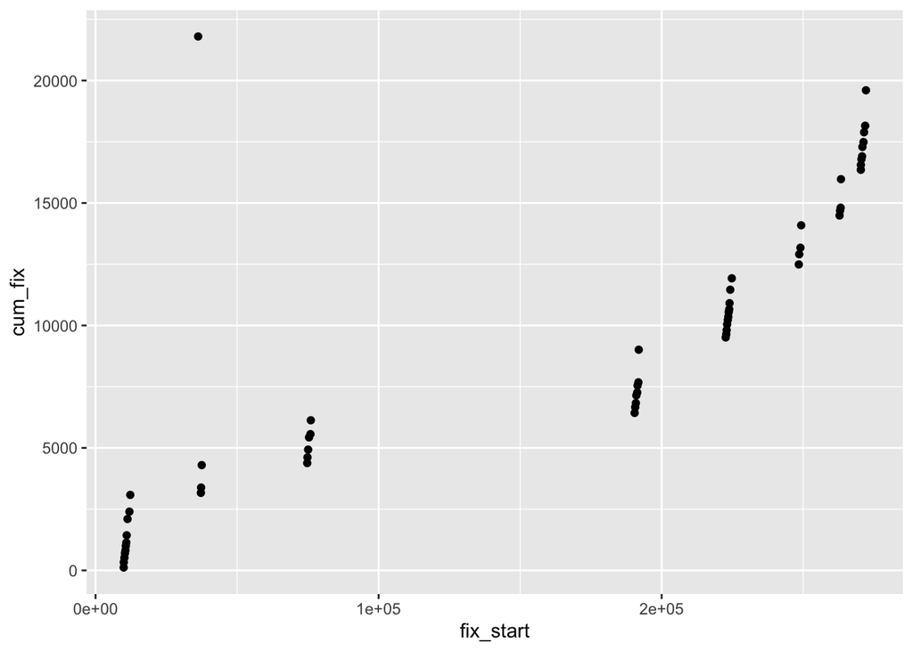

```r
this_trial_fixations %>%
  ggplot(.) +
  aes(x = fix_start, y = cum_fix) +
  geom_point()
```

To fix the scale, let’s just take the first set where the `fix_start` is less than 100,000.

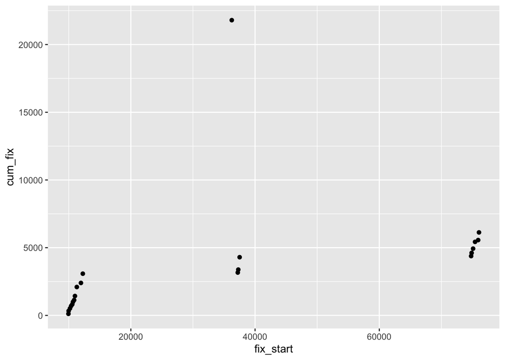

```r
this_trial_fixations %>%
  dplyr::filter(., fix_start < 100000) %>%
  ggplot(.) +
  aes(x = fix_start, y = cum_fix) +
  geom_point()
```

Even those look like trials. They’re spaced apart by 20,000+ milliseconds. Let’s filter even more.

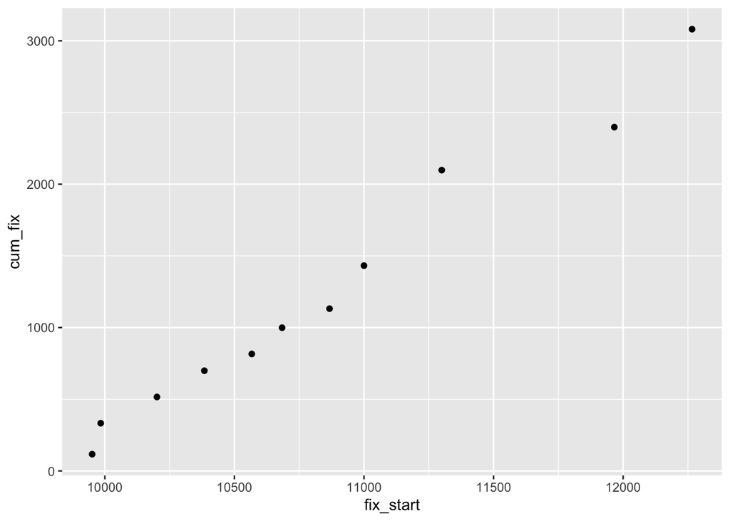

```r
this_trial_fixations %>%
  dplyr::filter(., fix_start < 20000) %>%
  ggplot(.) +
  aes(x = fix_start, y = cum_fix) +
  geom_point()
```

So, it looks like I need a way to parse by trial in order to make the cumulative sums work. I also need a way to determine what target the fixations are directed to. I think the fixation target is in the long set of columns I omitted.